# Forest Cover Type

# Réduction de dimension

#### Importance des attributs

```python
importance = [round(x*100,0) for x in models['randomForest_100'].feature_importances_]
importance = pd.DataFrame(importance,X_train.columns)
importance.rename(columns={0:'feat_importance'},inplace=True)
importance.sort_values(by='feat_importance',ascending=False)
```

|  | feat_importance |
| --- | --- |
| Elevation | 24.0 |
| Horizontal_Distance_To_Roadways | 9.0 |
| Horizontal_Distance_To_Fire_Points | 7.0 |
| Horizontal_Distance_To_Hydrology | 6.0 |
| Vertical_Distance_To_Hydrology | 5.0 |
| Hillshade_9am | 5.0 |
| Hillshade_3pm | 5.0 |
| Aspect | 5.0 |
| Slope | 4.0 |
| Hillshade_Noon | 4.0 |
| Wilderness_Area4 | 4.0 |
| Soil_Type3 | 2.0 |
| Soil_Type10 | 2.0 |
| Wilderness_Area3 | 2.0 |
| Soil_Type38 | 2.0 |
| Soil_Type39 | 2.0 |
| Soil_Type30 | 1.0 |
| Soil_Type29 | 1.0 |
| Soil_Type23 | 1.0 |
| Soil_Type22 | 1.0 |
| Soil_Type17 | 1.0 |
| Soil_Type12 | 1.0 |
| Soil_Type13 | 1.0 |
| Soil_Type40 | 1.0 |
| Soil_Type2 | 1.0 |
| Soil_Type4 | 1.0 |
| Soil_Type11 | 0.0 |
| Soil_Type28 | 0.0 |
| Wilderness_Area2 | 0.0 |
| Soil_Type1 | 0.0 |
| Soil_Type37 | 0.0 |
| Soil_Type36 | 0.0 |
| Soil_Type35 | 0.0 |
| Soil_Type34 | 0.0 |
| Soil_Type33 | 0.0 |
| Soil_Type32 | 0.0 |
| Soil_Type31 | 0.0 |
| Soil_Type27 | 0.0 |
| Soil_Type9 | 0.0 |
| Soil_Type26 | 0.0 |
| Soil_Type25 | 0.0 |
| Soil_Type24 | 0.0 |
| Soil_Type5 | 0.0 |
| Soil_Type6 | 0.0 |
| Soil_Type21 | 0.0 |
| Soil_Type20 | 0.0 |
| Soil_Type19 | 0.0 |
| Soil_Type18 | 0.0 |
| Soil_Type8 | 0.0 |
| Soil_Type16 | 0.0 |
| Soil_Type14 | 0.0 |

Pour l'importance des attributs, nous pouvons observer que la plupart des types de sols n'ont pas réellement d'impact dans notre modélisation. Nous pouvons donc les retirer et ne garder que les 2 ou 3 premiers attributs pour simplifier notre modélisation à l'avenir.

### Analyse en composantes principales

```python
pca = sk_de.PCA(n_components=2)
components = pca.fit_transform(X_norm)

X_red = pd.DataFrame(components,columns = ['principal component 1', 'principal component 2'],index=df.index)
X_red = pd.merge(X_red,df,how='left',left_index=True, right_index=True)
```

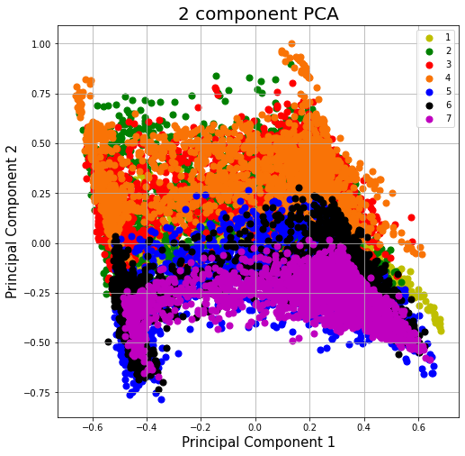

```python
# Représentation de la projection selon le Cover_Type
# Projection en 2 dimensions de notre jeu de données :

import matplotlib.pyplot as plt
import matplotlib.lines as plt_l
fig = plt.figure(figsize = (8,8))
ax = fig.add_subplot(1,1,1)
ax.set_xlabel('Principal Component 1', fontsize = 15)
ax.set_ylabel('Principal Component 2', fontsize = 15)
ax.set_title('2 component PCA', fontsize = 20)
labels = X_red.Cover_Type.unique()
labels_text = {1: 'Spruce/Fir', 2: 'Lodgepole Pine', 3: 'Ponderosa Pine', 4:'Cottonwood/Willow', 5:'Aspen', 6:'Douglas-fir', 7:'Krummholz'}
colors = {1:'r',2:'g',3:'b',4:'m',5:'y',6:'k',7:'xkcd:orange'}
for label_i in labels:
    indicesToKeep = X_red['Cover_Type'] == label_i
    ax.scatter(X_red.loc[indicesToKeep, 'principal component 1'], X_red.loc[indicesToKeep, 'principal component 2']
               , c = colors[label_i], s = 50,label=labels_text[label_i])
ax.legend(labels_text)
ax.grid()
```

L'analyse en composantes principales distinguée par les couvertures forestières montre:

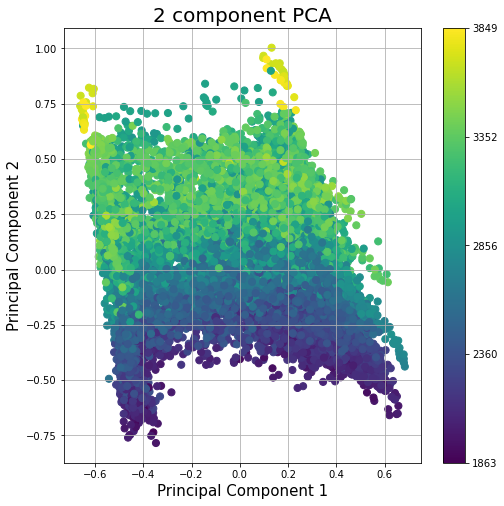

```python
# Représentation selon une des variables d'entrée
fig = plt.figure(figsize = (8,8))
ax = fig.add_subplot(1,1,1)
ax.set_xlabel('Principal Component 1', fontsize = 15)
ax.set_ylabel('Principal Component 2', fontsize = 15)
ax.set_title('2 component PCA', fontsize = 20)
points = ax.scatter(X_red.loc[:,'principal component 1'], X_red.loc[:, 'principal component 2']
               , c = X_red.loc[:,'Elevation'], s = 50)
v1 = np.linspace(X_red.loc[:,'Elevation'].min(),X_red.loc[:,'Elevation'].max(),5, endpoint=True)
cb = fig.colorbar(points,ticks=v1)

ax.grid()
```

L'analyse en composantes principales différenciés par l'élevation est intéressante, on constate une tendance qui se dégage vers l'axe 2 et donc une corrélation importante avec l'axe 2.